```python
import pandas as pd
import numpy as np
import matplotlib.pyplot as plt
import seaborn as sns
import missingno as msn
plt.rcParams['font.sans-serif'] = ['SimHei']  # 'WenQuanYi Zen Hei' 是一种常用的开源中文字体
plt.rcParams['axes.unicode_minus'] = False  # 解决负号显示问题
plt.rcParams['font.size'] = 14
```

# 1. 数据分析

以Area1为例

## 1.1 数据读取

- 一行数据是一天内的负荷变化情况，纵轴为各96个时次，时次分辨率为15min（这部分对应到论文里就是数据集介绍）

```python
data = pd.read_csv('data/Area1_Load.csv')
print(data.head())
print(data.head())
```

```
          YMD        T0000        T0015        T0030        T0045  \
0  2009-01-01  3210.842464  3104.507008  3037.705984  2960.176288
1  2009-01-02  2163.988288  2074.737568  1999.624960  1950.288448
2  2009-01-03  3109.127008  3015.901120  2938.305664  2869.375744
3  2009-01-04  3307.752544  3209.726368  3125.514016  3075.184864
4  2009-01-05  3295.415776  3278.379328  3232.313632  3160.731232

         T0100        T0115        T0130        T0145        T0200  ...  \
0  2889.226528  2827.697728  2772.514336  2720.470720  2666.586688  ...
1  1889.142112  1846.489600  1800.414304  1778.308000  1746.278368  ...
2  2815.772224  2777.295616  2725.377568  2704.334464  2665.855744  ...
3  3028.708768  2995.458208  2956.236256  2926.631392  2893.666048  ...
4  3124.226368  3092.294176  3064.081312  3034.584256  3007.335136  ...

         T2130        T2145        T2200        T2215        T2230  \
```

[output cut: 43 more lines]

## 1.2 总体统计特征分析

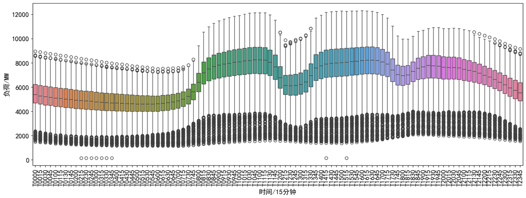

```python
# 通过绘制箱型图来观察每个时次的统计特征
plt.figure(figsize=(18, 6))
sns.boxplot(data=data.iloc[:, 1:97])
plt.xticks(rotation=90)
plt.savefig('image/数据处理/整体箱型图.png',dpi=600,bbox_inches='tight')
plt.xlabel('时间/15分钟')
plt.ylabel('负荷/MW')
plt.show()
```

## 1.3 数据处理

- 逻辑与上一节衔接

### 1.3.1 异常值处理

```python
time_cols = ['T0215', 'T0230', 'T0245', 'T0300', 'T0315', 'T0330', 'T0345', 'T1415', 'T1515']
for col in time_cols:
    data[col] = np.where(data[col] < 1000, (data[col].shift(1) + data[col].shift(-1)) / 2, data[col])
```

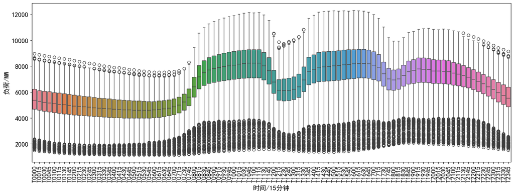

```python
# 对比填充前，发现明显异常值消除
plt.figure(figsize=(18, 6))
sns.boxplot(data=data.iloc[:, 1:97])
plt.xticks(rotation=90)
plt.savefig('image/数据处理/整体箱型图（填充后）.png',dpi=600,bbox_inches='tight')
plt.xlabel('时间/15分钟')
plt.ylabel('负荷/MW')
plt.show()
```

### 1.3.2 缺失值处理

- 无缺失值，故不作处理（缺失值可视化这个图可以不放，无关紧要）

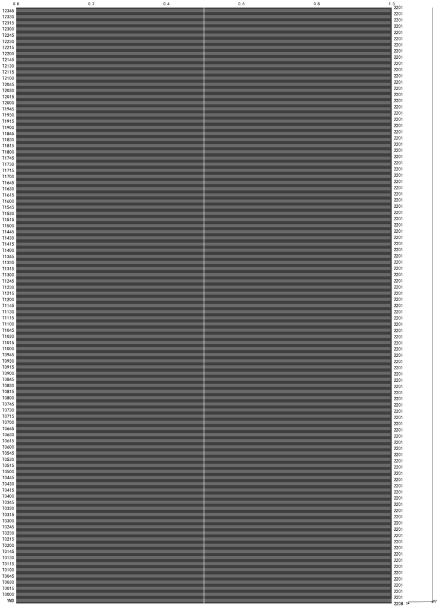

```python
msn.matrix(data, labels = False, label_rotation = 90)
# 展示每一列的缺失值数量条形图
msn.bar(data)
plt.savefig('image/数据处理/缺失值可视化.png', dpi=600,bbox_inches='tight')
plt.show()
```

## 1.4 负荷周期性分析

### 1.4.1 年负荷周期性分析

- 15min时间分辨数据太密集，不好观察，所以将时间分辨率上采样至“天”，来观察年周期特征

[figure not shown]

```python
plt.figure(figsize=(12, 6))
data['MaxLoad'] = data.iloc[:, 1:97].max(axis=1)
data['MinLoad'] = data.iloc[:, 1:97].min(axis=1)
data['MeanLoad'] = data.iloc[:, 1:97].mean(axis=1)
plt.plot(data['MaxLoad'], marker='*', linestyle='None', label='日最大负荷')
plt.plot(data['MinLoad'], marker='*', linestyle='None', label='日平均负荷')
plt.plot(data['MeanLoad'], marker='*', linestyle='None', label='日最小负荷')
plt.xlabel('时间/天')
plt.ylabel('负荷/MW')
plt.legend()
plt.savefig('image/数据处理/年负荷周期性分析.png', dpi=600,bbox_inches='tight')
plt.show()
```

### 1.4.2 季节负荷周期性分析

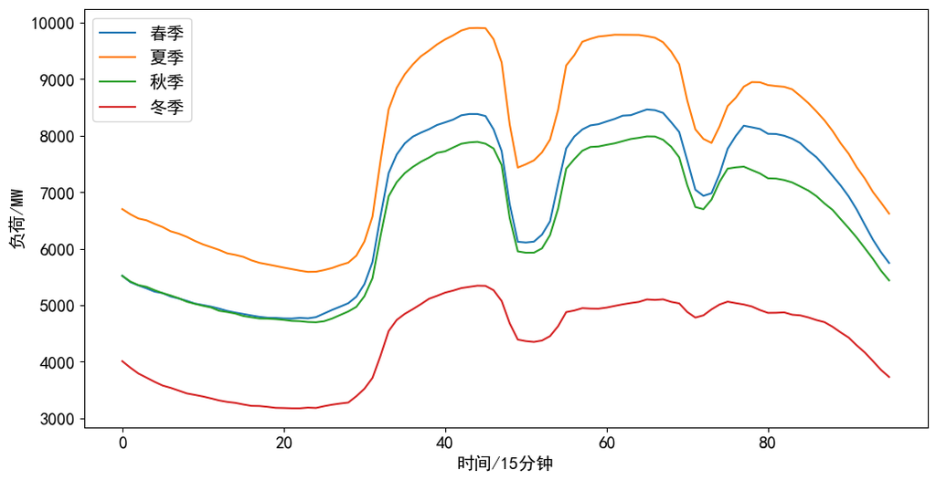

```python
# 选取2011年的春夏秋冬的各一天进行数据可视化
data = pd.read_csv('data/Area1_Load_clean.csv')
spring = data[(data['YMD'] == '2011-04-15')]
summer = data[(data['YMD'] == '2011-07-15')]
autumn = data[(data['YMD'] == '2011-10-15')]
winter = data[(data['YMD'] == '2012-01-15')]
plt.figure(figsize=(12, 6))
plt.plot(range(len(spring.iloc[0, 1:97])), spring.iloc[0, 1:97], linestyle='-', label='春季')
plt.plot(range(len(summer.iloc[0, 1:97])), summer.iloc[0, 1:97], linestyle='-', label='夏季')
plt.plot(range(len(autumn.iloc[0, 1:97])), autumn.iloc[0, 1:97], linestyle='-', label='秋季')
plt.plot(range(len(winter.iloc[0, 1:97])), winter.iloc[0, 1:97], linestyle='-', label='冬季')
# 添加标签
plt.xlabel('时间/15分钟')
plt.ylabel('负荷/MW')
plt.legend()
plt.savefig('image/数据处理/季节负荷周期性分析.png', dpi=600,bbox_inches='tight')
plt.show()
```

### 1.4.2 周负荷周期性分析

```python
# TODO:节假日权重更合理的分配
# 根据chinese——calendar包获取节假日信息
import chinese_calendar as calendar
from chinese_calendar import is_workday
# 对日期进行处理
data['YMD'] = pd.to_datetime(data['YMD'])
# 添加周几的信息
data['weekday'] = data['YMD'].dt.weekday
# 添加是否为工作日的信息
data['is_workday'] = data['YMD'].apply(is_workday).astype(int)
# 添加节假日的具体名称，如spring_festival等
# 加入节假日属性
Holiday = {"New Year's Day":10,"Spring Festival":30,"Tomb-sweeping Day":10,
           "Labour Day":10,"Dragon Boat Festival":10,
           "National Day":20,"Mid-autumn Festival":10}  # 创建一个空字典，用于存放节假日的名称和权重
Holiday_Info = [] # 创建一个空列表，用于存放节假日的权重
Holiday_Name = []  # 创建一个空列表，用于存放节假日的名称
time = pd.to_datetime(data['YMD'])  # 获取日期
for i in range(len(time)):  # 遍历日期
    t = time[i]  # 获取日期
    t_date = pd.to_datetime(t).date() # 将日期转换为时间格式
    on_holiday, holiday_name = calendar.get_holiday_detail(t_date)  # 获得节假日的布尔值和节假日名称
    if on_holiday == True:  # 如果是节假日
        if Holiday.get(holiday_name):  # 如果是列举节假日
            t_holiday = Holiday.get(holiday_name)  # 赋值为节假日的权重
        elif data['weekday'][i]>= 5:
            t_holiday = 5  # 如果是周末，权重赋值为5
        Holiday_Name.append(holiday_name)  # 将节假日名称添加到列表中
    else:
        t_holiday = 0  # 如果不是节假日，权重赋值为0
        Holiday_Name.append('None')
    Holiday_Info.append(t_holiday)  # 将权重添加到列表中

# Drop the existing "Holiday_Info" column if it already exists
if 'Holiday_Info' in data.columns:
    data = data.drop('Holiday_Info', axis=1)
if 'Holiday_Name' in data.columns:
    data = data.drop('Holiday_Name', axis=1)

data.insert(102,'Holiday_Info', Holiday_Info)
data.insert(103,'Holiday_Name', Holiday_Name)  # 将列表作为新的列插入到数据中

# 查看数据
print(data.head())
# 保存处理后的数据
data.to_csv('data/Area1_Load_clean.csv', index=False)
```

```
         YMD        T0000        T0015        T0030        T0045        T0100  \
0 2009-01-01  3210.842464  3104.507008  3037.705984  2960.176288  2889.226528
1 2009-01-02  2163.988288  2074.737568  1999.624960  1950.288448  1889.142112
2 2009-01-03  3109.127008  3015.901120  2938.305664  2869.375744  2815.772224
3 2009-01-04  3307.752544  3209.726368  3125.514016  3075.184864  3028.708768
4 2009-01-05  3295.415776  3278.379328  3232.313632  3160.731232  3124.226368

         T0115        T0130        T0145        T0200  ...        T2315  \
0  2827.697728  2772.514336  2720.470720  2666.586688  ...  2485.757536
1  1846.489600  1800.414304  1778.308000  1746.278368  ...  3587.174176
2  2777.295616  2725.377568  2704.334464  2665.855744  ...  3774.541120
3  2995.458208  2956.236256  2926.631392  2893.666048  ...  3767.990560
4  3092.294176  3064.081312  3034.584256  3007.335136  ...  4295.259520

         T2330        T2345      MaxLoad      MinLoad     MeanLoad  weekday  \
0  2382.696928  2276.210080  3210.842464  2122.434784  2573.974370        3
1  3424.568608  3266.948608  4865.440960  1616.353408  3479.023373        4
2  3602.281312  3444.148000  5183.229088  2489.030752  4026.499732        5
3  3602.398720  3477.076768  5164.950112  2679.780352  4076.881717        6
4  4106.356096  3933.511360  5852.397376  2822.751040  4548.918550        0

   is_workday  Holiday_Info    Holiday_Name
0           0            10  New Year's Day
1           0            10  New Year's Day
2           0            10  New Year's Day
3           1             0            None
4           1             0            None

[5 rows x 104 columns]
```

[figure not shown]

```python
# 选取2011年的春夏秋冬的星期一到星期天进行数据可视化
data = pd.read_csv('data/Area1_Load_clean.csv')
data['YMD'] = pd.to_datetime(data['YMD'])
# 判断所给日期是否从星期一开始
spring_start_weekday = pd.to_datetime('2011-04-11')
summer_start_weekday = pd.to_datetime('2011-07-11')
autumn_start_weekday = pd.to_datetime('2011-10-10')
winter_start_weekday = pd.to_datetime('2012-01-09')
# 判断start_weekday是否为星期一
assert spring_start_weekday.weekday() == 0
assert summer_start_weekday.weekday() == 0
assert autumn_start_weekday.weekday() == 0
assert winter_start_weekday.weekday() == 0
# 获取每个季节的数据
spring_week = data[(data['YMD'] >= spring_start_weekday) & (data['YMD'] < spring_start_weekday + pd.Timedelta(days=7))]
summer_week = data[(data['YMD'] >= summer_start_weekday) & (data['YMD'] < summer_start_weekday + pd.Timedelta(days=7))]
autumn_week = data[(data['YMD'] >= autumn_start_weekday) & (data['YMD'] < autumn_start_weekday + pd.Timedelta(days=7))]
winter_week = data[(data['YMD'] >= winter_start_weekday) & (data['YMD'] < winter_start_weekday + pd.Timedelta(days=7))]
# 将每个季节的一周数据连续在一起
spring_week = spring_week.iloc[:, 1:97].values.flatten()
summer_week = summer_week.iloc[:, 1:97].values.flatten()
autumn_week = autumn_week.iloc[:, 1:97].values.flatten()
winter_week = winter_week.iloc[:, 1:97].values.flatten()
# 画图
plt.figure(figsize=(12, 6))
plt.plot(range(len(spring_week)), spring_week, linestyle='-', label='春季')
plt.plot(range(len(summer_week)), summer_week, linestyle='-', label='夏季')
plt.plot(range(len(autumn_week)), autumn_week, linestyle='-', label='冬季')
plt.plot(range(len(winter_week)), winter_week, linestyle='-', label='秋季')
# 添加标签
plt.xlabel('时间/15分钟')
plt.ylabel('负荷/MW')
plt.legend()
plt.savefig('image/数据处理/周负荷周期性分析.png', dpi=600,bbox_inches='tight')
plt.show()
```

### 1.4.3 日负荷周期性分析

- 可以结合“image/周负荷周期性分析.png”对日负荷的周期性进行分析

## 1.5 不同因素对负荷的影响分析

### 1.5.1 日期类型对负荷的影响

- 主要研究研究工作日、双休日、节假日对负荷的影响，可以观察到，周末与工作日的负荷分布差异性较小，节假日与工作日的差异较大。随着节日的盛大程度，与工作日负荷的差异性就越大。为了在建模中考虑这种节日盛大程度对负荷的影响，构造了特征“Holiday_Info”用以存放节假日所对应的权重，其中权重采用人为经验，即节日越盛大，其权值越高，周末权重设置为5，非节日权重为0。其中具体权重设置，整理如下：

\begin{array}{|c|c|} \hline \text{节假日} & \text{权重} \\ \hline \text{春节} & 30 \\ \text{国庆节} & 20 \\ \text{元旦} & 10 \\ \text{清明节} & 10 \\ \text{劳动节} & 10 \\ \text{端午节} & 10 \\ \text{中秋节} & 10 \\ \text{周末} & 5 \\ \text{工作日} & 0 \\ \hline \end{array}

- 另外，观察到“1.4.2 周负荷周期性分析”的图中，负荷变化和周几也有一定的相关性，因此构造了特征“weekday”，其中[0,6]分别代表周一至至周日。

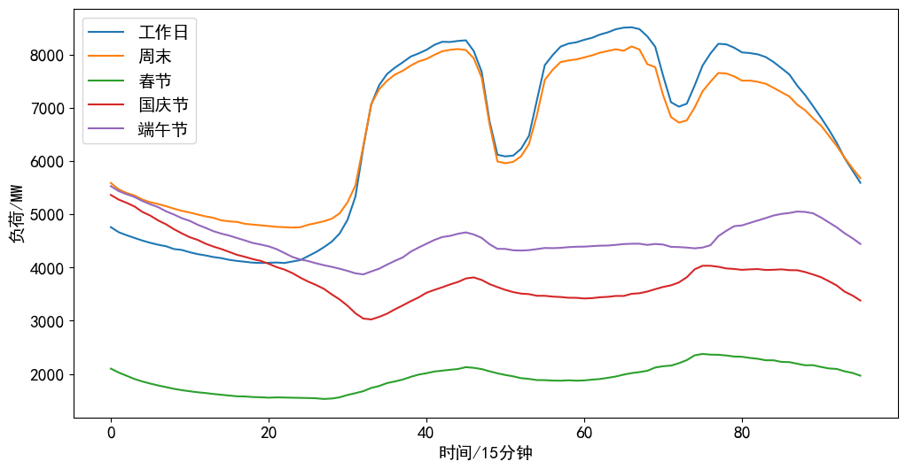

```python
# 选取2011年的工作日、双休日、节假日中的一天进行数据可视化
data = pd.read_csv('data/Area1_Load_clean.csv')
data['YMD'] = pd.to_datetime(data['YMD'])
# 选取一个周一
workday = data[(data['YMD'] == '2011-04-11')]
assert workday['YMD'].dt.weekday.values[0] == 0
# 选取一个周六
weekend = data[(data['YMD'] == '2011-04-16')]
assert weekend['YMD'].dt.weekday.values[0] == 5
# 选取2011年的春节假期
holiday = data[(data['Holiday_Name'] == 'Spring Festival')]
spring_festival = holiday[(holiday['YMD'] == '2011-02-02')]
assert spring_festival['Holiday_Name'].values[0] == 'Spring Festival'
# 选取2011年的国庆节
holiday = data[(data['Holiday_Name'] == 'National Day')]
national_day = holiday[(holiday['YMD'] == '2011-10-01')]
assert national_day['Holiday_Name'].values[0] == 'National Day'
# 选取2011年的国庆节
holiday = data[(data['Holiday_Name'] == 'Dragon Boat Festival')]
dragon_boat_festival = holiday[(holiday['YMD'] == '2011-06-06')]
assert dragon_boat_festival['Holiday_Name'].values[0] == 'Dragon Boat Festival'
# 画图
plt.figure(figsize=(12, 6))
plt.plot(range(len(workday.iloc[0, 1:97])), workday.iloc[0, 1:97], linestyle='-', label='工作日')
plt.plot(range(len(weekend.iloc[0, 1:97])), weekend.iloc[0, 1:97], linestyle='-', label='周末')
plt.plot(range(len(spring_festival.iloc[0, 1:97])), spring_festival.iloc[0, 1:97], linestyle='-', label='春节')
plt.plot(range(len(national_day.iloc[0, 1:97])), national_day.iloc[0, 1:97], linestyle='-', label='国庆节')
plt.plot(range(len(dragon_boat_festival.iloc[0, 1:97])), dragon_boat_festival.iloc[0, 1:97], linestyle='-', label='端午节')

# 添加标签
plt.xlabel('时间/15分钟')
plt.ylabel('负荷/MW')
plt.legend()
plt.savefig('image/数据处理/日期类型对负荷影响.png', dpi=600,bbox_inches='tight')
plt.show()
```

### 1.5.2 温度对负荷的影响

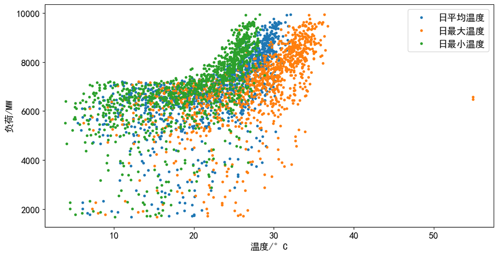

```python
# 选取2012年-2014年的天气数据对负荷进行分析
data = pd.read_csv('data/Area1_Load_clean.csv')
weather = pd.read_csv('data/Area1_Weather.csv')
# 对日期进行处理
data['YMD'] = pd.to_datetime(data['YMD'])
weather['YMD'] = pd.to_datetime(weather['YMD'])
# 选取2012年-2014年的数据
data = data[(data['YMD'] >= '2012-01-01') & (data['YMD'] < '2015-01-17')]
weather = weather[(weather['YMD'] >= '2012-01-01') & (weather['YMD'] < '2015-01-17')]
# 将日平均气温、日最高气温、日最低气温对应的日平均负荷进行可视化
plt.figure(figsize=(12, 6))
plt.plot(weather['Avg_Temperature'], data['MeanLoad'], linestyle='None', marker='.', label='日平均温度')
plt.plot(weather['Max_Temperature'], data['MeanLoad'], linestyle='None', marker='.', label='日最大温度')
plt.plot(weather['Min_Temperature'], data['MeanLoad'], linestyle='None', marker='.', label='日最小温度')
# 添加标签
plt.xlabel('温度/°C')
plt.ylabel('负荷/MW')
plt.legend()
plt.show()
```

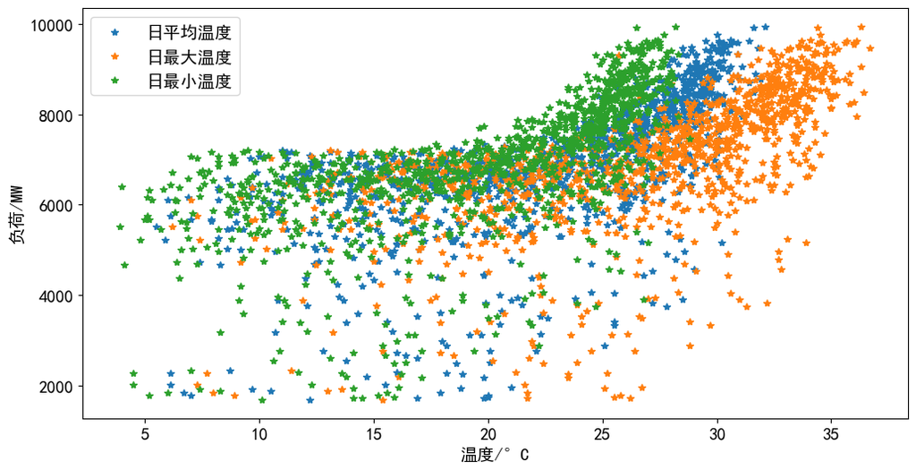

```python
# 大于50度的温度数据显然是异常值
# 将异常值使用前一天的数据进行替换
weather['Max_Temperature'] = np.where(weather['Max_Temperature'] > 50, weather['Max_Temperature'].shift(1), weather['Max_Temperature'])
weather['Avg_Temperature'] = np.where(weather['Avg_Temperature'] > 50, weather['Avg_Temperature'].shift(1), weather['Avg_Temperature'])
weather['Min_Temperature'] = np.where(weather['Min_Temperature'] > 50, weather['Min_Temperature'].shift(1), weather['Min_Temperature'])
# 重新画图
plt.figure(figsize=(12, 6))
plt.plot(weather['Avg_Temperature'], data['MeanLoad'], linestyle='None', marker='*', label='日平均温度')
plt.plot(weather['Max_Temperature'], data['MeanLoad'], linestyle='None', marker='*', label='日最大温度')
plt.plot(weather['Min_Temperature'], data['MeanLoad'], linestyle='None', marker='*', label='日最小温度')
# 添加标签
plt.xlabel('温度/°C')
plt.ylabel('负荷/MW')
plt.legend()
plt.savefig('image/数据处理/温度对负荷影响.png', dpi=600,bbox_inches='tight')
plt.show()
# 把处理后的数据保存
weather.to_csv('data/Area1_Weather_clean.csv', index=False)
```

### 1.5.3 降雨对负荷的影响

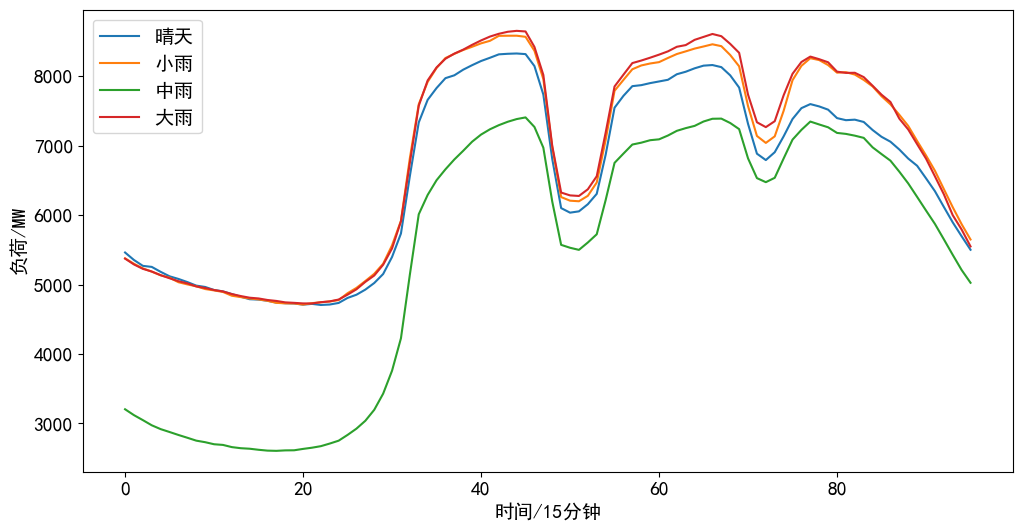

```python
# 选取晴天、小雨、中雨、大雨的数据对负荷进行分析
data = pd.read_csv('data/Area1_Load_clean.csv')
weather = pd.read_csv('data/Area1_Weather_clean.csv')
# 对日期进行处理
data['YMD'] = pd.to_datetime(data['YMD'])
weather['YMD'] = pd.to_datetime(weather['YMD'])
# 选取2013年6月的数据，避免其他因素影响
weather = weather[(weather['YMD'] >= '2013-04-01') & (weather['YMD'] < '2013-05-01')]
# 选取晴天、小雨、中雨、大雨中的一天
sunny = weather[(weather['Rainfall'] == 0)].sample(1)
light_rain = weather[(weather['Rainfall'] > 0) & (weather['Rainfall'] <= 10)].sample(1)
moderate_rain = weather[(weather['Rainfall'] > 10) & (weather['Rainfall'] <= 25)].sample(1)
heavy_rain = weather[(weather['Rainfall'] > 25)].sample(1)
sunny = data[(data['YMD'] == sunny['YMD'].values[0])]
light_rain = data[(data['YMD'] == light_rain['YMD'].values[0])]
moderate_rain = data[(data['YMD'] == moderate_rain['YMD'].values[0])]
heavy_rain = data[(data['YMD'] == heavy_rain['YMD'].values[0])]
# 画图
plt.figure(figsize=(12, 6))
plt.plot(range(len(sunny.iloc[0, 1:97])), sunny.iloc[0, 1:97], linestyle='-', label='晴天')
plt.plot(range(len(light_rain.iloc[0, 1:97])), light_rain.iloc[0, 1:97], linestyle='-', label='小雨')
plt.plot(range(len(moderate_rain.iloc[0, 1:97])), moderate_rain.iloc[0, 1:97], linestyle='-', label='中雨')
plt.plot(range(len(heavy_rain.iloc[0, 1:97])), heavy_rain.iloc[0, 1:97], linestyle='-', label='大雨')
# 添加标签
plt.xlabel('时间/15分钟')
plt.ylabel('负荷/MW')
plt.legend()
plt.savefig('image/数据处理/降雨对负荷影响.png', dpi=600,bbox_inches='tight')
plt.show()
```

### 1.5.4 湿度对负荷的影响

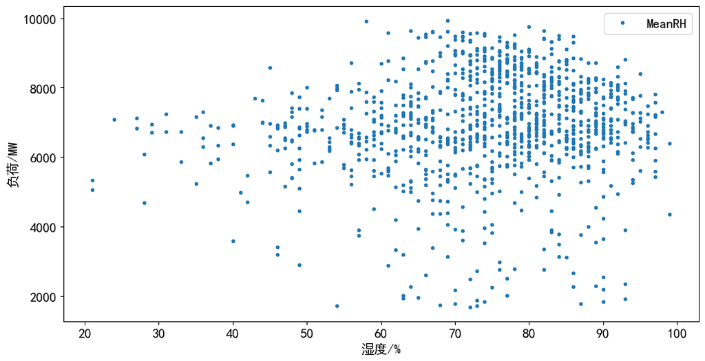

```python
# 选取2012年-2014年的相对湿度数据对负荷进行分析
data = pd.read_csv('data/Area1_Load_clean.csv')
weather = pd.read_csv('data/Area1_Weather_clean.csv')
# 对日期进行处理
data['YMD'] = pd.to_datetime(data['YMD'])
weather['YMD'] = pd.to_datetime(weather['YMD'])
# 选取2012年-2014年的数据
data = data[(data['YMD'] >= '2012-01-01') & (data['YMD'] < '2015-01-01')]
weather = weather[(weather['YMD'] >= '2012-01-01') & (weather['YMD'] < '2015-01-01')]
# 将日平均相对湿度对应的日平均负荷进行可视化
plt.figure(figsize=(12, 6))
plt.plot(weather['Avg_Humidity'], data['MeanLoad'], linestyle='None', marker='.', label='MeanRH')
# 添加标签
plt.xlabel('湿度/%')
plt.ylabel('负荷/MW')
plt.legend()
plt.savefig('image/数据处理/湿度对负荷影响.png', dpi=600,bbox_inches='tight')
plt.show()
```

## 1.5 相关性分析

### 1.5.1 互相关性

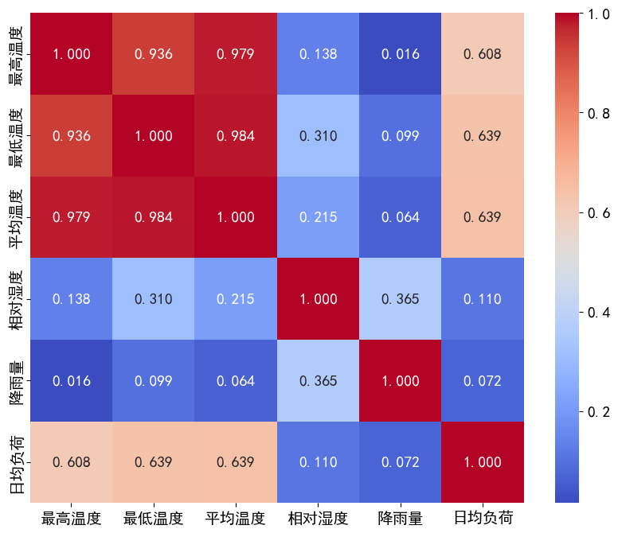

```python
# 最高温度 最低温度 平均温度 相对湿度 降雨量与负荷的相关性
# person计算相关性
# 将天气的日期数据与日平均负荷数据合并
data = pd.read_csv('data/Area1_Load_clean.csv')
weather = pd.read_csv('data/Area1_Weather_clean.csv')
# 对日期进行处理
data['YMD'] = pd.to_datetime(data['YMD'])
weather['YMD'] = pd.to_datetime(weather['YMD'])
# 选取2012年-2014年的数据
data = data[(data['YMD'] >= '2012-01-01') & (data['YMD'] < '2015-01-01')]
weather = weather[(weather['YMD'] >= '2012-01-01') & (weather['YMD'] < '2015-01-01')]
# 合并日平均负荷数据与天气数据
weather = weather.drop(['YMD'], axis=1)

mean_load = data['MeanLoad'].values
weather.insert(5, 'MeanLoad', mean_load)

weather.columns = ['最高温度','最低温度','平均温度','相对湿度','降雨量','日均负荷']
correlation = weather.corr()
plt.figure(figsize=(10, 8))
sns.heatmap(correlation, annot=True, cmap='coolwarm', fmt='.3f')
plt.savefig('image/数据处理/特征互相关性.png', dpi=600,bbox_inches='tight')
plt.show()
```

### 1.5.2 自相关

```python
# 将负荷数据进行整合，由每隔15分钟改为每隔一小时
data = pd.read_csv('data/Area1_Load_clean.csv')
# 对日期进行处理
data['YMD'] = pd.to_datetime(data['YMD'])
# 时间格式为T0000,T0015,T0030,T0045,T0100,T0115,T0130,T0145,T0200
# 将T0000-T2300的数据整合成每日0-23点的数据
# 创建另一个DataFrame，用于存放整合后的数据
data_hour = pd.DataFrame()
# 遍历日期
for i in range(len(data)):
    # 获取日期
    t = data['YMD'][i]
    # 获取负荷数据
    load = data.iloc[i, 1:97:4].values
    # 创建一个新的DataFrame，用于存放整合后的数据,第一列为时间，包含年月日小时,第二列为Load
    temp = pd.DataFrame({'Time': pd.date_range(t, periods=24, freq='H'), 'Load': load})
    data_hour = pd.concat([data_hour, temp], axis=0)
print(data_hour.head())
# 保存处理后的数据
data_hour.to_csv('data/Area1_Load_hour.csv', index=False)
```

```
                 Time         Load
0 2009-01-01 00:00:00  3210.842464
1 2009-01-01 01:00:00  2889.226528
2 2009-01-01 02:00:00  2666.586688
3 2009-01-01 03:00:00  2531.124064
4 2009-01-01 04:00:00  2422.123744
```

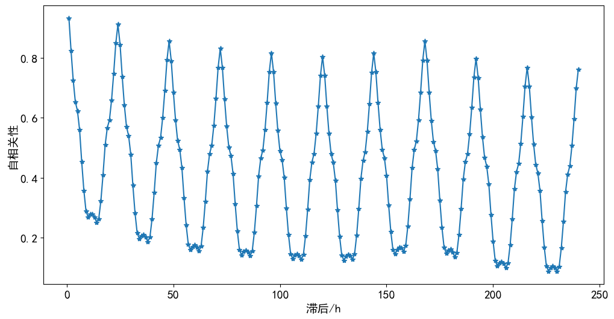

```python
# 求自相关系数
data = pd.read_csv('data/Area1_Load_hour.csv')
# 对日期进行处理
data['Time'] = pd.to_datetime(data['Time'])
autocorrelation = []
# 求自相关系数
for i in range(1, 241):
    autocorrelation.append(data['Load'].autocorr(lag=i)) # 调用pandas的autocorr函数计算自相关系数
# 画图
plt.figure(figsize=(12, 6))
plt.plot(range(1, 241), autocorrelation, linestyle='-', marker='*')
plt.xlabel('滞后/h')
plt.ylabel('自相关性')
plt.savefig('image/数据处理/负荷自相关性.png', dpi=600,bbox_inches='tight')
plt.show()
```